# Gini Index and Inequality

ID, Last Name, First Name

2024/01/24

## Short Abstract

> In this note, we study GINI index using WDI and compare with other index. In an OECD report, ‘OECD Regions and Cities at a Glance 2022’ [Link](https://read.oecd-ilibrary.org/urban-rural-and-regional-development/oecd-regions-and-cities-at-a-glance-2022_14108660-en#page1), S80/S20 ratios are used. We consider a question if the ratio is related to GINI index.

**Definition S80/S20 ratio**: The total income received by the 20% of people with the highest income in a region divided by the total income received by the 20% of people with the lowest income in the same region.

## Information of data

### Poverty and Inequality

**Distribution of income or consumption**

Gini Index: SI.POV.GINI [[Link](https://data.worldbank.org/indicator/SI.POV.GINI)]

Income share held by lowest 20%: SI.DST.FRST.20 [[Link](https://data.worldbank.org/indicator/SI.DST.FRST.20)]

Income share held by second 20%: SI.DST.02ND.20 [[Link](https://data.worldbank.org/indicator/SI.DST.02ND.20)]

Income share held by third 20%: SI.DST.03RD.20 [[Link](https://data.worldbank.org/indicator/SI.DST.03RD.20)]

Income share held by fourth 20%: SI.DST.04TH.20 [[Link](https://data.worldbank.org/indicator/SI.DST.04TH.20)]

Income share held by highest 20%: SI.DST.05TH.20 [[Link](https://data.worldbank.org/indicator/SI.DST.05TH.20)]

## Setup

Install a package `DescTools` first.

```r
library(tidyverse)
library(broom)
library(WDI)
library(DescTools)
```

## Introduction

### What is Gini index?

#### Gini Calculator

```r
GINI <- function(x){
  Lc(x)[c(1,2)] |> as.tibble() |> mutate(A = p, .after = 1) |>
  pivot_longer(-1, names_to = "name", values_to = "value") |>
  ggplot(aes(p, value, fill = name)) +
    geom_area(position = "identity") +
    annotate("text", x = 0.25, y = 0.75, label = paste("GINI = A/(A+L) = ", round(Gini(x, unbiased = FALSE), digits = 2))) +
    scale_y_continuous(labels = scales::percent_format(accuracy = 1))+
    scale_x_continuous(labels = scales::percent_format(accuracy = 1)) +
    labs(title = "GINI Index", x = "People", y = "Wealth", fill = "")}
```

#### Example 1

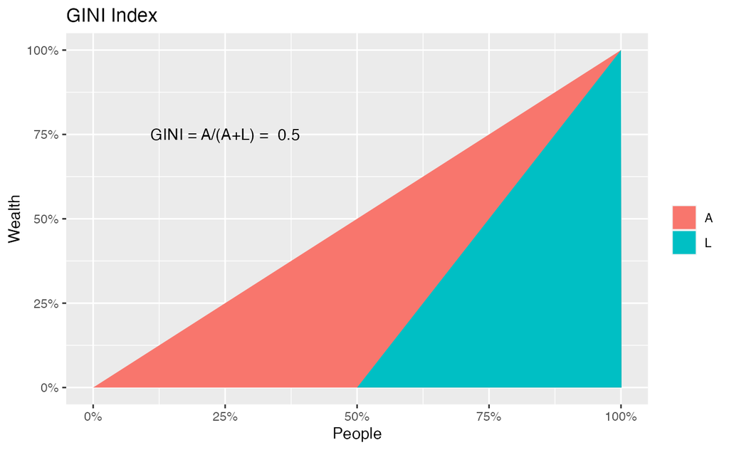

```r
x <- c(0,1)
GINI(x)
```

#### Example 2

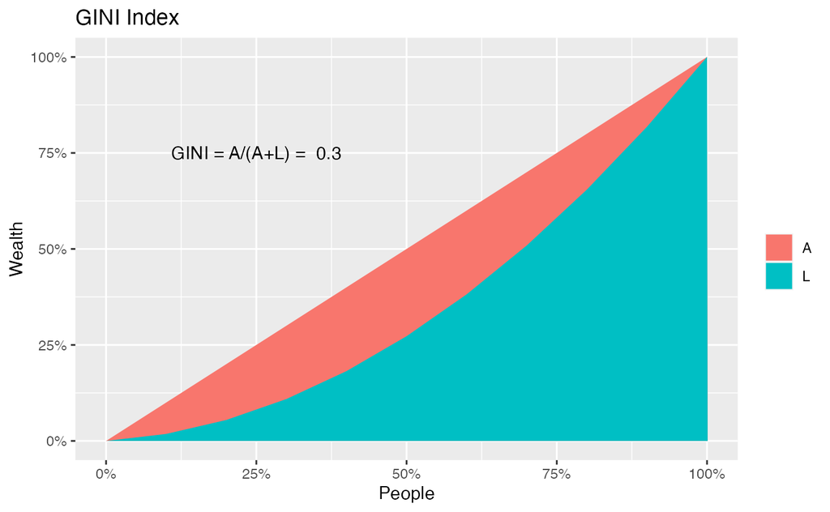

```r
y <- c(1,2,3,4,5,6,7,8,9,10)
GINI(y)
```

#### Example 3

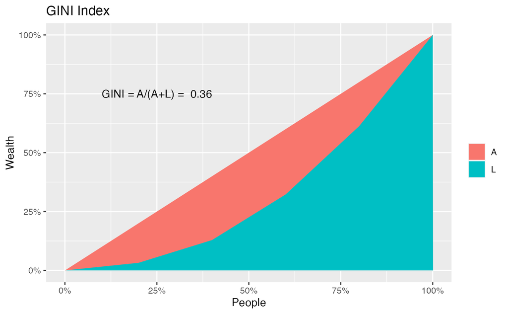

```r
z <- c(1/12,3/12,6/12,9/12,1)
GINI(z)
```

## Importing Data

```r
df_gini <- WDI(indicator = c(gini = "SI.POV.GINI",
                            `0-20` = "SI.DST.FRST.20",
                            `20-40` = "SI.DST.02ND.20",
                            `40-60` = "SI.DST.03RD.20",
                            `60-80` = "SI.DST.04TH.20",
                            `80-100` = "SI.DST.05TH.20"))
```

```r
write_csv(df_gini, "data/gini.csv")
```

```r
df_gini <- read_csv("data/gini.csv")
```

```r
REGION <- c("1A", "1W", "4E", "6F", "6N", "6X", "7E", "8S", "A4", "A5",
"A9", "B1", "B2", "B3", "B4", "B6", "B7", "B8", "C4", "C5", "C6",
"C7", "C8", "C9", "D2", "D3", "D4", "D5", "D6", "D7", "EU", "F1",
"F6", "M1", "M2", "N6", "OE", "R6", "S1", "S2", "S3", "S4", "T2",
"T3", "T4", "T5", "T6", "T7", "V1", "V2", "V3", "V4", "XC", "XD",
"XE", "XF", "XG", "XH", "XI", "XJ", "XL", "XM", "XN", "XO", "XP",
"XQ", "XT", "XU", "XY", "Z4", "Z7", "ZB", "ZF", "ZG", "ZH", "ZI",
"ZJ", "ZQ", "ZT")
```

## Viewing Data

```r
df_gini
```

| country | iso2c | iso3c | year | gini | 0-20 | 20-40 | 40-60 | 60-80 | 80-100 |
| --- | --- | --- | --- | --- | --- | --- | --- | --- | --- |
| Afghanistan | AF | AFG | 1960 | NA | NA | NA | NA | NA | NA |
| Afghanistan | AF | AFG | 1961 | NA | NA | NA | NA | NA | NA |
| Afghanistan | AF | AFG | 1962 | NA | NA | NA | NA | NA | NA |
| Afghanistan | AF | AFG | 1963 | NA | NA | NA | NA | NA | NA |
| Afghanistan | AF | AFG | 1964 | NA | NA | NA | NA | NA | NA |
| Afghanistan | AF | AFG | 1965 | NA | NA | NA | NA | NA | NA |
| Afghanistan | AF | AFG | 1966 | NA | NA | NA | NA | NA | NA |
| Afghanistan | AF | AFG | 1967 | NA | NA | NA | NA | NA | NA |
| Afghanistan | AF | AFG | 1968 | NA | NA | NA | NA | NA | NA |
| Afghanistan | AF | AFG | 1969 | NA | NA | NA | NA | NA | NA |

[output cut: 990 more lines]

```r
df_gini_long <- df_gini |>
  pivot_longer(`0-20`:`80-100`)
df_gini_long
```

| country | iso2c | iso3c | year | gini | name | value |
| --- | --- | --- | --- | --- | --- | --- |
| Afghanistan | AF | AFG | 1960 | NA | 0-20 | NA |
| Afghanistan | AF | AFG | 1960 | NA | 20-40 | NA |
| Afghanistan | AF | AFG | 1960 | NA | 40-60 | NA |
| Afghanistan | AF | AFG | 1960 | NA | 60-80 | NA |
| Afghanistan | AF | AFG | 1960 | NA | 80-100 | NA |
| Afghanistan | AF | AFG | 1961 | NA | 0-20 | NA |
| Afghanistan | AF | AFG | 1961 | NA | 20-40 | NA |
| Afghanistan | AF | AFG | 1961 | NA | 40-60 | NA |
| Afghanistan | AF | AFG | 1961 | NA | 60-80 | NA |
| Afghanistan | AF | AFG | 1961 | NA | 80-100 | NA |

[output cut: 990 more lines]

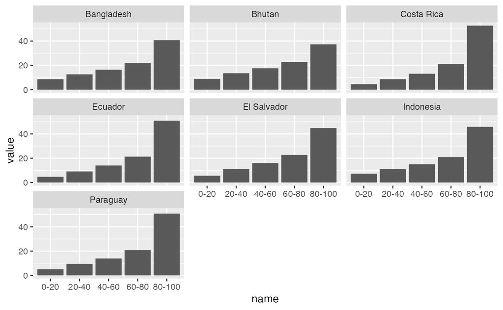

```r
df_gini_long |> filter(year == 2022) |>
  filter(name != "gini") |>  drop_na(value) |>
  ggplot(aes(name, value)) + geom_col() + facet_wrap(~country)
```

## Transforming Data

We add a new column with the value `s80/s20` = `80-100`/`0-20`.

```r
df_gini <- df_gini |> mutate(`s80/s20` = `80-100`/`0-20`)
df_gini
```

| country | iso2c | iso3c | year | gini | 0-20 | 20-40 | 40-60 | 60-80 | 80-100 | s80/s20 |
| --- | --- | --- | --- | --- | --- | --- | --- | --- | --- | --- |
| Afghanistan | AF | AFG | 1960 | NA | NA | NA | NA | NA | NA | NA |
| Afghanistan | AF | AFG | 1961 | NA | NA | NA | NA | NA | NA | NA |
| Afghanistan | AF | AFG | 1962 | NA | NA | NA | NA | NA | NA | NA |
| Afghanistan | AF | AFG | 1963 | NA | NA | NA | NA | NA | NA | NA |
| Afghanistan | AF | AFG | 1964 | NA | NA | NA | NA | NA | NA | NA |
| Afghanistan | AF | AFG | 1965 | NA | NA | NA | NA | NA | NA | NA |
| Afghanistan | AF | AFG | 1966 | NA | NA | NA | NA | NA | NA | NA |
| Afghanistan | AF | AFG | 1967 | NA | NA | NA | NA | NA | NA | NA |
| Afghanistan | AF | AFG | 1968 | NA | NA | NA | NA | NA | NA | NA |
| Afghanistan | AF | AFG | 1969 | NA | NA | NA | NA | NA | NA | NA |

[output cut: 990 more lines]

## Visualization and Analysis

### Number of Data in Each Year

Check the number of data available in year year.

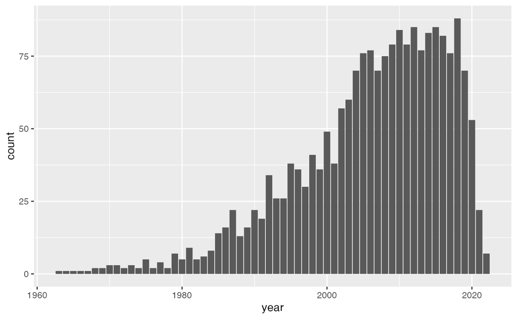

```r
df_gini |> drop_na(gini, `0-20`, `80-100`) |>
  ggplot(aes(year)) + geom_bar()
```

### Correlation of Three Indicators

We calculate the correlations among three indicators, GINI, top 20% and s80/s20 ratio.

1. Correlation using all available values.
2. Correlation using all available values of countries.
3. Correlation using all available values of countries in 2018.

```r
df_gini |> drop_na(gini, `0-20`, `80-100`) |> select(gini, `80-100`, `s80/s20`) |>
  cor() |> as.data.frame()
```

|  | gini | 80-100 | s80/s20 |
| --- | --- | --- | --- |
| gini | 1.0000000 | 0.9943488 | 0.8663291 |
| 80-100 | 0.9943488 | 1.0000000 | 0.8592673 |
| s80/s20 | 0.8663291 | 0.8592673 | 1.0000000 |

```r
df_gini |> drop_na(gini, `0-20`, `80-100`) |>
  filter(!(iso2c %in% REGION)) |> select(gini, `80-100`, `s80/s20`) |>
  cor() |> as.data.frame()
```

|  | gini | 80-100 | s80/s20 |
| --- | --- | --- | --- |
| gini | 1.0000000 | 0.9943488 | 0.8663291 |
| 80-100 | 0.9943488 | 1.0000000 | 0.8592673 |
| s80/s20 | 0.8663291 | 0.8592673 | 1.0000000 |

```r
df_gini |> drop_na(gini, `0-20`, `80-100`) |> filter(year == 2018) |>
  filter(!(iso2c %in% REGION)) |> select(gini, `80-100`, `s80/s20`) |>
  cor() |> as.data.frame()
```

|  | gini | 80-100 | s80/s20 |
| --- | --- | --- | --- |
| gini | 1.0000000 | 0.9894834 | 0.9343159 |
| 80-100 | 0.9894834 | 1.0000000 | 0.9074783 |
| s80/s20 | 0.9343159 | 0.9074783 | 1.0000000 |

**Observations:**

- The correlation between GINI index and the top 20% share of income is very close to 1.
- We chose 2018 as it is the year we have the most available values.
- There are no regional values of these three indices. So the values of the first two coincide.

### Scatter Plots

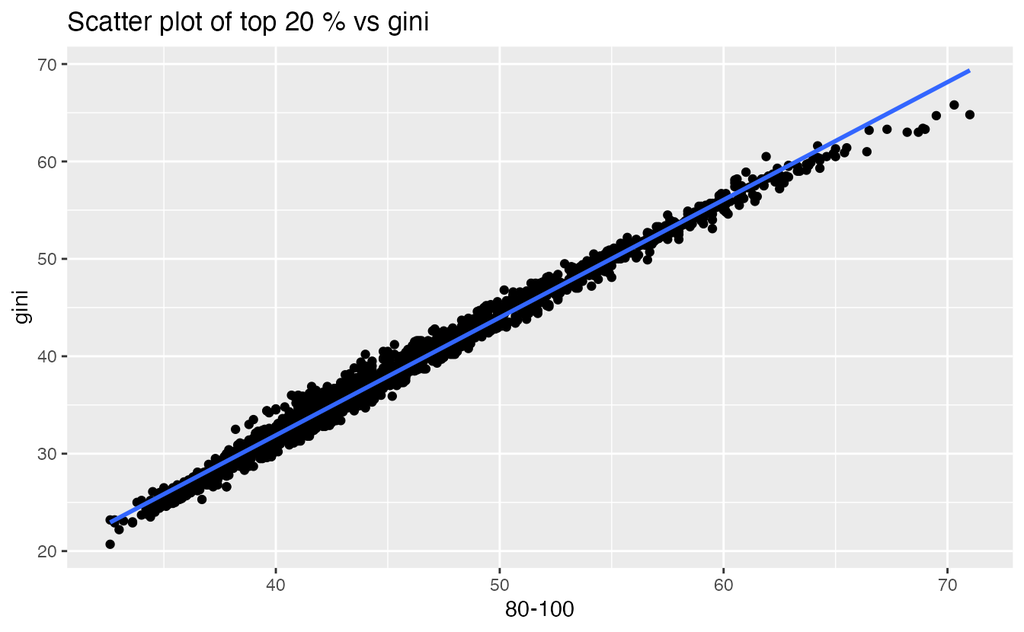

```r
df_gini |> drop_na(gini, `0-20`, `80-100`) |>
  ggplot(aes(`80-100`, gini)) + geom_point() +
  geom_smooth(formula = 'y~x', method = "lm", se = FALSE) +
  labs(title = "Scatter plot of top 20 % vs gini")
```

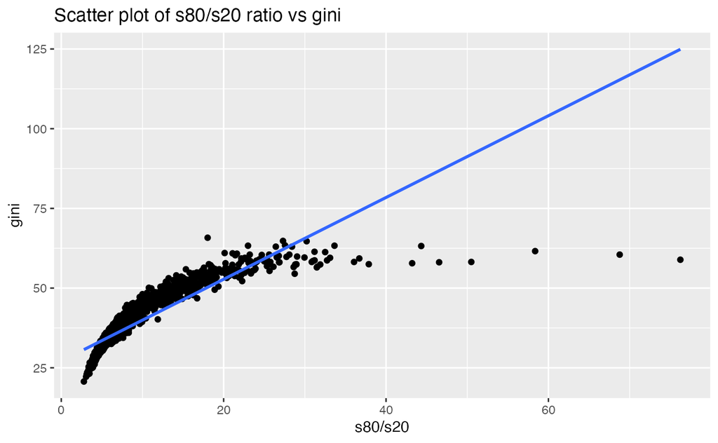

```r
df_gini |> drop_na(gini, `0-20`, `80-100`) |>
  ggplot(aes(`s80/s20`, gini)) + geom_point() +
  geom_smooth(formula = 'y~x', method = "lm", se = FALSE) +
  labs(title = "Scatter plot of s80/s20 ratio vs gini")
```

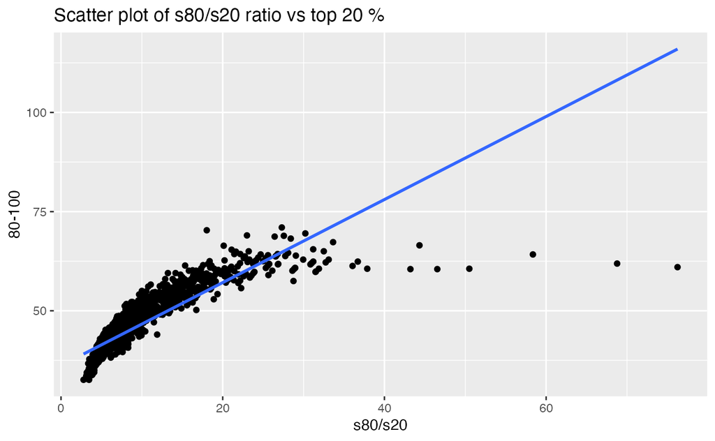

```r
df_gini |> drop_na(gini, `0-20`, `80-100`) |>
  ggplot(aes(`s80/s20`, `80-100`)) + geom_point() +
  geom_smooth(formula = 'y~x', method = "lm", se = FALSE) +
  labs(title = "Scatter plot of s80/s20 ratio vs top 20 %")
```

## Models

We set three models.

```r
model_gini_top20 <- df_gini |> lm(gini ~ `80-100`, data = _)
model_gini_8020 <- df_gini |> lm(gini ~ `s80/s20`, data = _)
model_8020_top20 <- df_gini |> lm(`s80/s20` ~ `80-100`, data = _)
```

### Summary of the model `gini` ~ `top 20%`

```r
model_gini_top20 |> summary()
```

```
Call:
lm(formula = gini ~ `80-100`, data = df_gini)

Residuals:
    Min      1Q  Median      3Q     Max
-4.5592 -0.6513 -0.0618  0.5784  3.4748

Coefficients:
              Estimate Std. Error t value Pr(>|t|)
(Intercept) -16.456298   0.131171  -125.5   <2e-16 ***
`80-100`      1.208670   0.002879   419.8   <2e-16 ***
---
Signif. codes:  0 ‘***’ 0.001 ‘**’ 0.01 ‘*’ 0.05 ‘.’ 0.1 ‘ ’ 1

Residual standard error: 0.9416 on 2005 degrees of freedom
  (14751 observations deleted due to missingness)
Multiple R-squared:  0.9887,    Adjusted R-squared:  0.9887
F-statistic: 1.762e+05 on 1 and 2005 DF,  p-value: < 2.2e-16
```

### Summary of the model `gini` ~ `s80/s20`

```r
model_gini_8020 |> summary()
```

```
Call:
lm(formula = gini ~ `s80/s20`, data = df_gini)

Residuals:
    Min      1Q  Median      3Q     Max
-66.009  -2.487   0.140   2.871  15.560

Coefficients:
            Estimate Std. Error t value Pr(>|t|)
(Intercept) 27.12397    0.17022  159.35   <2e-16 ***
`s80/s20`    1.28242    0.01652   77.65   <2e-16 ***
---
Signif. codes:  0 ‘***’ 0.001 ‘**’ 0.01 ‘*’ 0.05 ‘.’ 0.1 ‘ ’ 1

Residual standard error: 4.429 on 2004 degrees of freedom
  (14752 observations deleted due to missingness)
Multiple R-squared:  0.7505,    Adjusted R-squared:  0.7504
F-statistic:  6029 on 1 and 2004 DF,  p-value: < 2.2e-16
```

### Summary of the model `s80/s20` ~ `top 20%`

```r
model_8020_top20 |> summary()
```

```
Call:
lm(formula = `s80/s20` ~ `80-100`, data = df_gini)

Residuals:
   Min     1Q Median     3Q    Max
-8.242 -1.450 -0.068  0.975 56.544

Coefficients:
              Estimate Std. Error t value Pr(>|t|)
(Intercept) -23.327946   0.427285   -54.6   <2e-16 ***
`80-100`      0.705481   0.009382    75.2   <2e-16 ***
---
Signif. codes:  0 ‘***’ 0.001 ‘**’ 0.01 ‘*’ 0.05 ‘.’ 0.1 ‘ ’ 1

Residual standard error: 3.064 on 2004 degrees of freedom
  (14752 observations deleted due to missingness)
Multiple R-squared:  0.7383,    Adjusted R-squared:  0.7382
F-statistic:  5655 on 1 and 2004 DF,  p-value: < 2.2e-16
```

### broom::tidy and broom::glance

```r
tidy(model_gini_top20) |> rbind(tidy(model_gini_8020)) |> rbind(tidy(model_8020_top20))
```

| term | estimate | std.error | statistic | p.value |
| --- | --- | --- | --- | --- |
| (Intercept) | -16.4562976 | 0.131170595 | -125.45722 | 0 |
| `80-100` | 1.2086696 | 0.002879472 | 419.75393 | 0 |
| (Intercept) | 27.1239695 | 0.170220702 | 159.34589 | 0 |
| `s80/s20` | 1.2824204 | 0.016516238 | 77.64604 | 0 |
| (Intercept) | -23.3279462 | 0.427284685 | -54.59579 | 0 |
| `80-100` | 0.7054807 | 0.009381588 | 75.19843 | 0 |

```r
glance(model_gini_top20) |> rbind(glance(model_gini_8020)) |> rbind(glance(model_8020_top20))
```

| r.squared | adj.r.squared | sigma | statistic | p.value | df | logLik | AIC | BIC | deviance | df.residual | nobs |
| --- | --- | --- | --- | --- | --- | --- | --- | --- | --- | --- | --- |
| 0.9887485 | 0.9887429 | 0.9415813 | 176193.361 | 0 | 1 | -2725.999 | 5457.997 | 5474.81 | 1777.584 | 2005 | 2007 |
| 0.7505262 | 0.7504017 | 4.4291673 | 6028.907 | 0 | 1 | -5830.743 | 11667.485 | 11684.30 | 39313.517 | 2004 | 2006 |
| 0.7383404 | 0.7382098 | 3.0642943 | 5654.804 | 0 | 1 | -5091.744 | 10189.487 | 10206.30 | 18817.358 | 2004 | 2006 |

## Conclusion

The GINI index and the income share held by highest 20% is strongly correlated. The relation is even stronger than the correlation between the GINI index and the `s80/s20` ratio.

## Calculation Model of Gini Index

```r
df_gini_calc <- df_gini |>
  mutate(`0` = 0, `20` = `0-20`,
         `40` = `0-20` + `20-40`,
         `60` = `0-20` + `20-40` + `40-60`,
         `80` = `0-20` + `20-40` + `40-60` + `60-80`,
         `100` = 100) |>
  select(-c(`0-20`:`60-80`))
df_gini_calc %>% drop_na()
```

| country | iso2c | iso3c | year | gini | 80-100 | s80/s20 | 0 | 20 | 40 | 60 | 80 | 100 |
| --- | --- | --- | --- | --- | --- | --- | --- | --- | --- | --- | --- | --- |
| Albania | AL | ALB | 1996 | 27.0 | 36.1 | 3.923913 | 0 | 9.2 | 22.9 | 40.6 | 63.9 | 100 |
| Albania | AL | ALB | 2002 | 31.7 | 40.4 | 4.809524 | 0 | 8.4 | 21.0 | 37.5 | 59.7 | 100 |
| Albania | AL | ALB | 2005 | 30.6 | 39.2 | 4.666667 | 0 | 8.4 | 21.3 | 38.3 | 60.8 | 100 |
| Albania | AL | ALB | 2008 | 30.0 | 39.0 | 4.382022 | 0 | 8.9 | 22.0 | 38.8 | 61.0 | 100 |
| Albania | AL | ALB | 2012 | 29.0 | 37.8 | 4.247191 | 0 | 8.9 | 22.1 | 39.4 | 62.2 | 100 |
| Albania | AL | ALB | 2014 | 34.6 | 41.7 | 5.957143 | 0 | 7.0 | 18.5 | 34.9 | 58.2 | 100 |
| Albania | AL | ALB | 2015 | 32.8 | 40.6 | 5.272727 | 0 | 7.7 | 19.8 | 36.3 | 59.3 | 100 |
| Albania | AL | ALB | 2016 | 33.7 | 41.2 | 5.643836 | 0 | 7.3 | 19.1 | 35.5 | 58.7 | 100 |
| Albania | AL | ALB | 2017 | 33.1 | 40.7 | 5.355263 | 0 | 7.6 | 19.6 | 36.1 | 59.4 | 100 |
| Albania | AL | ALB | 2018 | 30.1 | 38.2 | 4.835443 | 0 | 7.9 | 20.9 | 38.4 | 61.7 | 100 |

[output cut: 990 more lines]

```r
df_gini_calc_long <- df_gini_calc |>  pivot_longer(`0`:`100`, names_to = "classes", values_to = "cumulative_share") |> mutate(classes = as.numeric(classes))
df_gini_calc_long %>% drop_na()
```

| country | iso2c | iso3c | year | gini | 80-100 | s80/s20 | classes | cumulative_share |
| --- | --- | --- | --- | --- | --- | --- | --- | --- |
| Albania | AL | ALB | 1996 | 27.0 | 36.1 | 3.923913 | 0 | 0.0 |
| Albania | AL | ALB | 1996 | 27.0 | 36.1 | 3.923913 | 20 | 9.2 |
| Albania | AL | ALB | 1996 | 27.0 | 36.1 | 3.923913 | 40 | 22.9 |
| Albania | AL | ALB | 1996 | 27.0 | 36.1 | 3.923913 | 60 | 40.6 |
| Albania | AL | ALB | 1996 | 27.0 | 36.1 | 3.923913 | 80 | 63.9 |
| Albania | AL | ALB | 1996 | 27.0 | 36.1 | 3.923913 | 100 | 100.0 |
| Albania | AL | ALB | 2002 | 31.7 | 40.4 | 4.809524 | 0 | 0.0 |
| Albania | AL | ALB | 2002 | 31.7 | 40.4 | 4.809524 | 20 | 8.4 |
| Albania | AL | ALB | 2002 | 31.7 | 40.4 | 4.809524 | 40 | 21.0 |
| Albania | AL | ALB | 2002 | 31.7 | 40.4 | 4.809524 | 60 | 37.5 |

[output cut: 990 more lines]

```r
df_gini_f <- df_gini_calc_long |> group_by(country, year) |>
  drop_na(gini) |>
  reframe(gini, gini_spline = round(100-AUC(classes, cumulative_share, method = "spline")/50, digits = 1), gini_trapezoid = round(100-AUC(classes, cumulative_share)/50, digits = 1), `80-100`, `s80/s20`) |>
  distinct(country, year, gini, gini_spline, gini_trapezoid, `80-100`, `s80/s20`)
df_gini_f
```

| country | year | gini | gini_spline | gini_trapezoid | 80-100 | s80/s20 |
| --- | --- | --- | --- | --- | --- | --- |
| Albania | 1996 | 27.0 | 26.4 | 25.4 | 36.1 | 3.923913 |
| Albania | 2002 | 31.7 | 30.6 | 29.4 | 40.4 | 4.809524 |
| Albania | 2005 | 30.6 | 29.7 | 28.5 | 39.2 | 4.666667 |
| Albania | 2008 | 30.0 | 28.9 | 27.7 | 39.0 | 4.382022 |
| Albania | 2012 | 29.0 | 28.1 | 27.0 | 37.8 | 4.247191 |
| Albania | 2014 | 34.6 | 33.9 | 32.6 | 41.7 | 5.957143 |
| Albania | 2015 | 32.8 | 32.0 | 30.8 | 40.6 | 5.272727 |
| Albania | 2016 | 33.7 | 33.1 | 31.8 | 41.2 | 5.643836 |
| Albania | 2017 | 33.1 | 32.2 | 30.9 | 40.7 | 5.355263 |
| Albania | 2018 | 30.1 | 29.6 | 28.4 | 38.2 | 4.835443 |

[output cut: 990 more lines]

```r
df_gini_f |> drop_na(gini, gini_spline, gini_trapezoid, `80-100`, `s80/s20`) |> select(gini, gini_spline, gini_trapezoid, `80-100`, `s80/s20`) |> cor() |> as.data.frame()
```

|  | gini | gini_spline | gini_trapezoid | 80-100 | s80/s20 |
| --- | --- | --- | --- | --- | --- |
| gini | 1.0000000 | 0.9993752 | 0.9992505 | 0.9943488 | 0.8663291 |
| gini_spline | 0.9993752 | 1.0000000 | 0.9999799 | 0.9913027 | 0.8666667 |
| gini_trapezoid | 0.9992505 | 0.9999799 | 1.0000000 | 0.9908249 | 0.8665828 |
| 80-100 | 0.9943488 | 0.9913027 | 0.9908249 | 1.0000000 | 0.8592673 |
| s80/s20 | 0.8663291 | 0.8666667 | 0.8665828 | 0.8592673 | 1.0000000 |

**Observation:**

- Since gini_spline and gini_trapezoid are calculated using the definition of the gini index, they are strongly correlated, though they are not exactly equal.

## Lorenz Curve

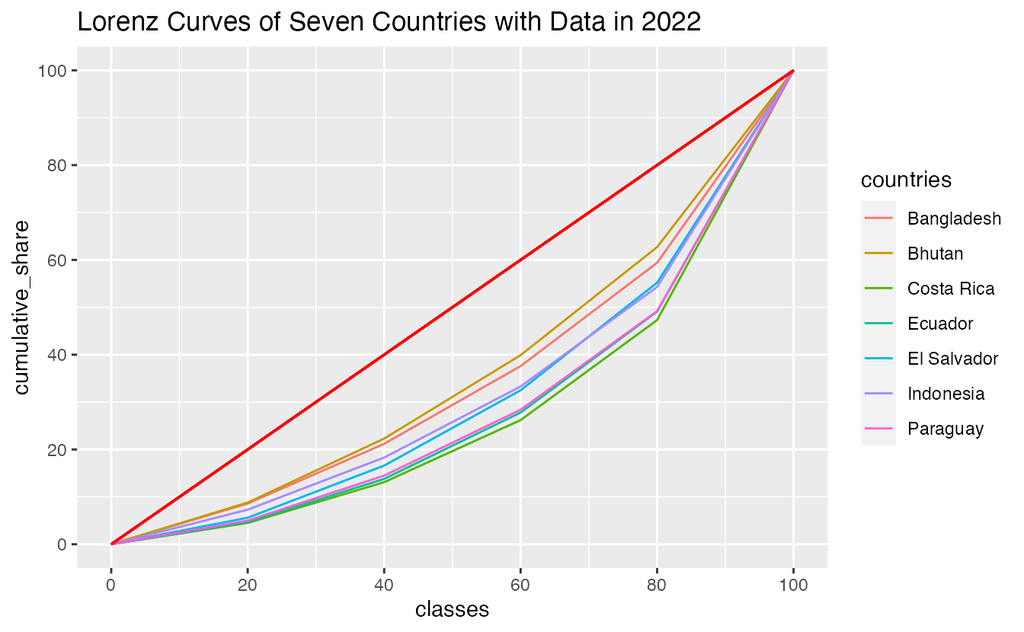

```r
df_gini_calc_long |> filter(year == 2022) |> drop_na(gini) |>
  ggplot() +
  geom_line(aes(classes, cumulative_share, col = country)) +
  geom_segment(aes(x = 0, y = 0, xend = 100, yend = 100, col = country), color = 'red') +
  scale_x_continuous(breaks = seq(0,100,by=20)) +
  scale_y_continuous(breaks = seq(0,100,by=20)) +
  labs(title = "Lorenz Curves of Seven Countries with Data in 2022", col = "countries")
```